# Композиция классификаторов

$X$ - пространство объектов;  
$Y$ - пространство ответов;  
$y: X \rightarrow Y$ - неизвестная функция.

**Дано:**  
$\{x_1, \ldots, x_l\}\subset X$ - обучающая выборка (training sample);  
$y_i=y(x_i), i=1,\ldots,l$ - известные ответы.

**Найти:**  
$a: X \rightarrow Y$ - алгоритм, приближающий $y$ на всем множестве $X$.

$a(x) = C(F(b_1(x), \ldots, b_T(x)))$, где

$b_i: X\rightarrow R$, $i=1,\ldots,T$ - базовые алгоритмы,

$F: R^T\rightarrow R$ - корректирующая операция,

$C: R\rightarrow Y$ - решающее правило,

$R$ - пространство оценок.

## Примеры пространств оценок и решающих правил

*Пример 1*

Классификация на 2 класса, $Y=\{-1, +1\}$.

$$ a(x) = sign(b(x)), $$

где $R=\mathbb{R}$, $b: X\rightarrow\mathbb{R}$, $C(b)=sign(b)$.

*Пример 2*

Классификация на M класса, $Y=\{1,\ldots, M\}$.

$$ a(x) = \arg\max_{y\in Y}(b_y(x)), $$

где $R=\mathbb{R}^M$, $b:X\rightarrow\mathbb{R}^M$, $C(b_1,\ldots,b_M)=\arg\max_{y\in Y}b_y$.

## Примеры корректирующих операций

*Пример 1.* Простое голосование.

$$ F(b_1(x), \ldots, b_T(x)) = \frac{1}{T}\sum_{t=1}^Tb_t(x),\ \ \ x\in X $$

*Пример 2.* Взвешенное голосование.

$$ F(b_1(x), \ldots, b_T(x)) = \sum_{t=1}^T\alpha_tb_t(x),\ \ \ x\in X, \ \ \ \alpha_t\in \mathbb{R} $$

*Пример 3.* Смесь алгоритмов.

$$ F(b_1(x), \ldots, b_T(x)) = \sum_{t=1}^Tg_t(x)b_t(x),\ \ \ x\in X, \ \ \ g_t: X\rightarrow\mathbb{R} $$

### Простое голосование

**Идея:** натренируем много *разных* алгоритмов.

Чтобы они были разными, можно:

- обучать их на разных подвыборках (bagging - bootstrap aggregation);
- обучать их на разных подмножествах признаков (RSM - random subspace method).

*Пример*: Random forest

### Взвешенное голосование

Разберем задачу бинарной классификации.

$$ a(x) = sign\big(\sum_{t=1}^T\alpha_tb_t(x)\big),\ \ \ x\in X $$

Возьмем в качестве функционала качества - число ошибок на $X^l$:

$$ Q_T = \sum_{i=1}^\ell\Big[y_i\sum_{t=1}^T\alpha_t b_t(x_i)\lt0\Big] $$

Основные эвристики

- фиксация $\alpha_1 b_1(x),\ldots, \alpha_{t-1}b_{t-1}(x)$ при добавлении $\alpha_t b_t(x)$;
- гладкая аппроксимация пороговой функции потерь $[M\le0]$.

[figure not shown]

Будем брать в качестве функции аппроксимации $e^{-M}$. Отметим, что $[M\le0]\le e^{-M}.$

Тогда можно оценивать функционал качества следующим образом:

$$ \sum_{i=1}^\ell\Big[y_i\sum_{t=1}^T\alpha_t b_t(x_i)\lt0\Big]=Q_T\le\tilde{Q}_T=\sum_{i=1}^\ell\exp\big(-y_i\sum_{t=1}^T\alpha_tb_t(x_i)\big)=\\ \sum_{i=1}^\ell\exp\big(-y_i\sum_{t=1}^{T-1}\alpha_tb_t(x_i)\big)\exp(-y_i\alpha_Tb_T(x_i)) $$

Обозначим:

$$ w_i = \exp\big(-y_i\sum_{t=1}^{T-1}\alpha_tb_t(x_i)\big) $$$$ \tilde{w}_i=w_i \big/ \sum_{j=1}^\ell w_j $$

$\tilde{W}^\ell=(\tilde{w}_1, \ldots, \tilde{w}_\ell)$

Пусть задан вектор весов $U^\ell=(u_1, \ldots, u_\ell)$. Введем взвешенные числа ошибочных и правильных классификаций:

$$ N(b, U^\ell) = \sum_{i=1}^\ell u_i[b(x_i)=-y_i] $$$$ P(b, U^\ell)=\sum_{i=1}^\ell u_i[b(x_i)=y_i] $$

**Теорема.** Пусть для любого нормированного вектора весов $U^\ell$ существует алгоритм $b\in B$, классифицирующий выборку хотя бы немного лучше, чем наугад: $N(b, U^\ell)<\frac{1}{2}$. Тогда минимум функционала $\tilde{Q}_T$ достигается при

$$ b_T = \arg\min_{b\in B}N(b, \tilde{W}^\ell) $$$$ \alpha_T=\frac{1}{2}\ln\frac{1-N(b_T, \tilde{W}^\ell)}{N(b_T, \tilde{W}^\ell)} $$

#### Алгоритм AdaBoost

Дано: обучающая выборка $X^\ell$, параметр $T$.

Инициализиция весов объектов: $w_i=\frac{1}{\ell}$, $i=1, \ldots, \ell$.

Для всех $t=1, \ldots, T$

$ \ \ \ \ \ \ $обучить базовый алгоритм $b_t=\arg\min_b N(b, W^\ell)$;

$ \ \ \ \ \ \ \alpha_t=\frac{1}{2}\ln\frac{1-N(b_t, W^\ell)}{N(b_t, W^\ell)}$;

$ \ \ \ \ \ \ $обновить веса объектов $w_i=w_i\exp(-\alpha_ty_ib_t(x_i))$, $i=1, \ldots, \ell$;

$ \ \ \ \ \ \ $нормировать веса объектов $w_0=\sum_{j=1}^\ell w_j$, $w_i=w_i/w_0$, $i=1,\ldots, \ell$.

#### Эвристики

**Базовые классификаторы:**

- эффективны простые классификаторы: решающие деревья, пороговые правила;
- бустинг на сильных классификаторах, например, SVM не эффективен.

**Отсев шума:** отбросить объекты с наибольшими $w_i$.

**Переобучение:** наблюдается, но слабо.

#### Сложности при использовании бустинга

- Чрезмерная чувствительность к выбросам из-за $e^{-M}$;
- Неинтерпретируемость;
- Композиции из "сильных" алгоритмов получаются неудачными;
- Требуются достаточно длинные обучающие выборки.

#### Gradient Boosting

$$ a(x) = \sum_{t=1}^T\alpha_tb_t(x), \ \ \ x\in X, \ \ \ \alpha_t\in\mathbb{R}_+ $$

Функционал качества с произвольной функцией потерь $L(a, y)$:

$$ Q(\alpha, b, X^\ell)=\sum_{i=1}^\ell L\Big(\sum_{t=1}^{T-1}\alpha_tb_t(x_i)+\alpha b(x_i), y_i\Big), $$

Текущее приближение:

$$ f_{T-1, i} = \sum_{t=1}^{T-1}\alpha_tb_t(x_i) $$

Следующее приближение:

$$ f_{T, i} = \sum_{t=1}^{T-1}\alpha_tb_t(x_i)+\alpha b(x_i) $$

$g_i=L'(f_{T-1, i}, y_i)$ - компоненты вектора градиента, $\alpha$ - градиентный шаг.

**Идея:** будем искать такой базовый алгоритм $b_T$, чтобы вектор $(b_T(x_i))_{i=1}^\ell$ приближал вектор антиградиента $(-g_i)_{i=1}^\ell$:

$$ b_T = \arg\min_b\sum_{i=1}^\ell(b(x_i)+g_i)^2 $$

#### Алгоритм Gradient Boosting

Дано: обучающая выборка $X^\ell$, параметр $T$.

Инициализиция весов объектов: $f_i=0$, $i=1, \ldots, \ell$.

Для всех $t=1, \ldots, T$

$ \ \ \ \ \ \ $базовый алгоритм, приближающий антиградиент $b_t=\arg\min_b \sum_{i=1}^\ell(b(x_i)+L'(f_i, y_i))^2$;

$ \ \ \ \ \ \ $задача одномерной минимизации $\alpha_t=\arg\min_{\alpha\gt0}\sum_{i=1}^\ell L(f_i+\alpha b_t(x_i), y_i)$;

$ \ \ \ \ \ \ $обновление вектора значений на объектах выборки: $f_i=f_i+\alpha_t b_t(x_i)$, $i=1, \ldots, \ell$.

#### XGBoost - реализация Gradient Boosting

Базовые классификаторы:

$$ b(x) = \sum_{j=1}^J w_j[x\in R_j], $$

где $R_j$ - область пространства, покрываемая листом $j$, $w_j$ - вес листа, $J$ - число листьев в дереве.

Функционал качества:

$$ Q(b, \{w_j\}_{j=1}^J, X^\ell)=\sum_{i=1}^\ell\Big(\sum_{t=1}^{T-1}\alpha_tb_t(x_i)+\alpha b(x_i), y_i\Big) + \\ +\gamma J + \mu\sum_{j=1}^J\big|w_j\big| + \frac{\lambda}{2}\sum_{j=1}^Jw_j^2\rightarrow\min_{b, \{w_j\}} $$

XGBoost предполагает 2 способа использования:

- sklearn-совместимые классы XGBClassifier, XGBRegressor
- "оригинальная" python-библиотека

```python
xgboost_regr = XGBRegressor()
for fold_index, (train_index, test_index) in enumerate(kf):
    xgboost_regr.fit(X[train_index], y[train_index])
    print("RMSE on fold {}: {}".format(
        fold_index,
        mean_squared_error(y[test_index], xgboost_regr.predict(X[test_index]))
    ))
```

```
RMSE on fold 0: 14.744231434919653
RMSE on fold 1: 9.251750777127478
RMSE on fold 2: 11.209489557252008
RMSE on fold 3: 5.925723233538298
RMSE on fold 4: 12.351955760805211
RMSE on fold 5: 8.979855598558842
```

## Особенности

Написан на C++, есть обертки на Python, R, Java, Scala

Умеет обрабатывать разреженные матрицы

Категориальные признаки нужно приводить к числовому виду

Встроено множество различных функций потерь:

- reg:linear
- reg:logistic
- binary:logistic
- ...
- имеется возможность реализовать свою функцию потерь

Позволяет извлекать "важности признаков" (`get_fscore`)

Позволяет рисовать деревья (`plot_tree`)

#### Настройка

`max_depth` - максимальная глубина дерева. Слишком большая глубина ведет к переобучению

`min_child_weight` - минимальная сумма весов в листе

`colsample_bytree` - сэмплирование по признакам

- Выбираем относительно большую learning_rate ($ \eta \in [0.05, 0.3]$), подбираем оптимальное число деревьев для выбранного $ \eta $
- Настраиваем параметры деревьев, начиная с самых значимых (max_depth, min_child_weight, gamma, colsample_bytree)
- Настраиваем регуляризации ($ \lambda, \alpha $)
- Уменьшаем learning_rate, пропорционально увеличиваем число деревьев

### Сравнение бустинга и бэггинга

- Бустинг лучше для больших обучающих выборок и для классов с границами сложной формы;
- Бэггинг и RSM лучше для коротких обучающих выборок;
- RSM хорош в тех случаях, когда признаков больше, чем объектов, или когда много неинформативных признаков; Бэггинг и RSM эффективно распараллеливаются, бустинг выполняется строго последовательно;
- Короткие композиции из сильных алгоритмов типа SVM строить труднее, чем длинные из слабых.

### Разложение ошибки на шум, вариацию и смещению.

Задача регрессии: $y=\mathbb{R}$.

Квадратичная функция потерь: $L(y, a)=(a(x)-y)^2$.

Вероятностная постановка: $X^l=(x_i, y_i)_{i=1}^l\sim p(x, y)$.

Метод обучения: $\mu: 2^X\rightarrow A$.

Среднеквадратичный риск:

$$ R(a) = E_{x, y}(a(x) - y)^2 = \int_X\int_Y(a(x)-y)^2p(x, y)dxdy $$

Минимум среднеквадратичного риска:

$$ a^*(x) = E(y|x) = \int_Yyp(y|x)dy $$

Средний ответ обученного алгоритма:

$$ \overline{a}(x) = E_{X^l}(\mu(X^l)(x)) $$

Мера качества метода обучения $\mu$:

$$ Q(\mu) = E_{X^l}E_{x, y}(\mu(X^l)(x)-y)^2 $$

В случае квадратичной функции потерь для любого $\mu$ выполнено

$Q(\mu) = E_{x, y}\big(a^*(x)-y\big)^2 + E_{x, y}\big(\overline{a}(x)-a^*(x)\big)^2 + E_{x, y}E_{X^l}\big(\mu(X^l)(x)-\overline{a}(x)\big)^2$

(шум + смещение + разброс)

[figure not shown]

*Пример.* Рассмотрим вероятностную модель данных: $p(y|x) = f(x) + N(0, \sigma^2)$.

В качестве регрессора выберем метод $k$ ближайших соседей. Тогда

$$ a^*(x)=f(x) $$$$ \overline{a}(x)=E_{X^\ell}\frac{1}{k}\sum_{j=1}^{k}f(x^{(j)}), $$

где $x^{(j)}$ - $j$-й сосед объекта $x$.

Тогда

$$ Q(\mu) = \sigma^2+E_{x,y}\big(\overline{a}(x)-f(x)\big)^2 + \frac{1}{k}\sigma^2 $$

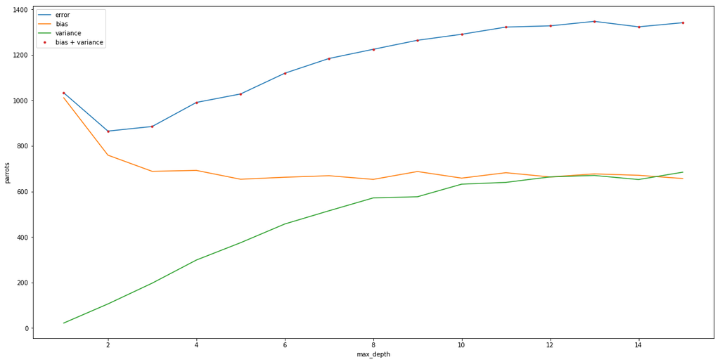

```python
plot_error_composition(param_name, param_values, error_dt, bias_dt, variance_dt)
```

## Stacking

[figure not shown]